# R Notebook: Artificaial Neural Networks for mushrooms classification problem

# #######################Solution to mushrooms problem using ANN

Helper funtion to create a directory on local filesystem

```r
mkdirs <- function(fp) {
    if(!file.exists(fp)) {
        dir.create(dirname(fp), showWarnings=FALSE, recursive = TRUE)
    }
}
```

Helper function to install and load any package

```r
# Function to Install and Load R Packages
installAndLoad <- function(Required_Packages)
{
    Remaining_Packages <- Required_Packages[!(Required_Packages %in% installed.packages()[,"Package"])];
    if(length(Remaining_Packages))
    {
        install.packages(Remaining_Packages);
    }
    for(package_name in Required_Packages)
    {
        library(package_name,character.only=TRUE,quietly=TRUE);
    }
}
```

Following code will load mushrooms data into dataframe. It will try to load the file from “data/mushrooms.csv” file on local computer. If its not available, it will download it from web and store it locally so we don’t have to download it again when we rerun the program again.

```r
loadData <- function(filepath, url, header=FALSE) {
  # load the CSV file from the local directory if it exists
  if(file.exists(filepath))
    dataset <- read.csv(filename, header=TRUE)
  else {
    # load the library
    installAndLoad(c("RCurl"));
    # download the file
    downloaded <- getURL(url, ssl.verifypeer=FALSE)
    # treat the text data as a steam so we can read from it
    connection <- textConnection(downloaded)
    # parse the downloaded data as CSV
    dataset <- read.csv(connection, header=header)
    # Add headers to dataset
    column_names = c("class", "cap-shape", "cap-surface", "cap-color", "bruises", "odor",
                     "gill-attachment", "gill-spacing", "gill-size", "gill-color", "stalk-shape",
                     "stalk-root", "stalk-surface-above-ring", "stalk-surface-below-ring",
                     "stalk-color-above-ring", "stalk-color-below-ring", "veil-type", "veil-color",
                     "ring-number", "ring-type", "spore-print-color", "population", "habitat")

    colnames(dataset) <- column_names
    #Expand e and p to edible and posonous
    dataset$class = sapply(dataset$class, function(x){ifelse(x=='e', 'edible', 'poisonous')})
    #Save file locally
    if(!file.exists(filepath)) {
      mkdirs(filepath)
    }
    write.csv(file=filepath, x=dataset, row.names = FALSE)
  }

  #return dataset
  dataset
}
```

*********************************Main program start here********************************** Load data file

```r
# define the filename
filename <- file.path(getwd(), "data", "mushrooms.csv")
# specify the URL for the mushroom data CSV
url <-'https://archive.ics.uci.edu/ml/machine-learning-databases/mushroom/agaricus-lepiota.data'
#Call loadData function
mushrooms_data <- loadData(filename, url)
```

Check dataset

```r
# preview the first 5 rows
head(mushrooms_data)
```

|  | class | cap.shape | cap.surface | cap.color | bruises | odor | gill.attachment | gill.spacing | gill.size | gill.color | stalk.shape | stalk.root | stalk.surface.above.ring | stalk.surface.below.ring | stalk.color.above.ring | stalk.color.below.ring | veil.type | veil.color | ring.number | ring.type | spore.print.color | population | habitat |
| --- | --- | --- | --- | --- | --- | --- | --- | --- | --- | --- | --- | --- | --- | --- | --- | --- | --- | --- | --- | --- | --- | --- | --- |
| 1 | p | x | s | n | t | p | f | c | n | k | e | e | s | s | w | w | p | w | o | p | k | s | u |
| 2 | e | x | s | y | t | a | f | c | b | k | e | c | s | s | w | w | p | w | o | p | n | n | g |
| 3 | e | b | s | w | t | l | f | c | b | n | e | c | s | s | w | w | p | w | o | p | n | n | m |
| 4 | p | x | y | w | t | p | f | c | n | n | e | e | s | s | w | w | p | w | o | p | k | s | u |
| 5 | e | x | s | g | f | n | f | w | b | k | t | e | s | s | w | w | p | w | o | e | n | a | g |
| 6 | e | x | y | y | t | a | f | c | b | n | e | c | s | s | w | w | p | w | o | p | k | n | g |

Explore some details about data. We have 22 predictors and its a binary classification problem

```r
#Dimentions of data
dim(mushrooms_data)
```

```
[1] 8124   23
```

```r
#Summary of Data
summary(mushrooms_data)
```

```
 class    cap.shape cap.surface   cap.color    bruises       odor      gill.attachment
 e:4208   b: 452    f:2320      n      :2284   f:4748   n      :3528   a: 210
 p:3916   c:   4    g:   4      g      :1840   t:3376   f      :2160   f:7914
          f:3152    s:2556      e      :1500            s      : 576
          k: 828    y:3244      y      :1072            y      : 576
          s:  32                w      :1040            a      : 400
          x:3656                b      : 168            l      : 400
                                (Other): 220            (Other): 484
 gill.spacing gill.size   gill.color   stalk.shape stalk.root stalk.surface.above.ring
 c:6812       b:5612    b      :1728   e:3516      ?:2480     f: 552
 w:1312       n:2512    p      :1492   t:4608      b:3776     k:2372
                        w      :1202               c: 556     s:5176
                        n      :1048               e:1120     y:  24
                        g      : 752               r: 192
                        h      : 732
                        (Other):1170
 stalk.surface.below.ring stalk.color.above.ring stalk.color.below.ring veil.type veil.color
 f: 600                   w      :4464           w      :4384           p:8124    n:  96
 k:2304                   p      :1872           p      :1872                     o:  96
 s:4936                   g      : 576           g      : 576                     w:7924
 y: 284                   n      : 448           n      : 512                     y:   8
                          b      : 432           b      : 432
                          o      : 192           o      : 192
                          (Other): 140           (Other): 156
 ring.number ring.type spore.print.color population habitat
 n:  36      e:2776    w      :2388      a: 384     d:3148
 o:7488      f:  48    n      :1968      c: 340     g:2148
 t: 600      l:1296    k      :1872      n: 400     l: 832
             n:  36    h      :1632      s:1248     m: 292
             p:3968    r      :  72      v:4040     p:1144
                       b      :  48      y:1712     u: 368
                       (Other): 144                 w: 192
```

# veil.type is same for all observations. We can drop it

```r
mushrooms_data$veil_type = NULL  # remove veil_type because all are partial, unnecessary column
```

```r
#structure of data
str(mushrooms_data)
```

```
'data.frame':   8124 obs. of  23 variables:
 $ class                   : Factor w/ 2 levels "e","p": 2 1 1 2 1 1 1 1 2 1 ...
 $ cap.shape               : Factor w/ 6 levels "b","c","f","k",..: 6 6 1 6 6 6 1 1 6 1 ...
 $ cap.surface             : Factor w/ 4 levels "f","g","s","y": 3 3 3 4 3 4 3 4 4 3 ...
 $ cap.color               : Factor w/ 10 levels "b","c","e","g",..: 5 10 9 9 4 10 9 9 9 10 ...
 $ bruises                 : Factor w/ 2 levels "f","t": 2 2 2 2 1 2 2 2 2 2 ...
 $ odor                    : Factor w/ 9 levels "a","c","f","l",..: 7 1 4 7 6 1 1 4 7 1 ...
 $ gill.attachment         : Factor w/ 2 levels "a","f": 2 2 2 2 2 2 2 2 2 2 ...
 $ gill.spacing            : Factor w/ 2 levels "c","w": 1 1 1 1 2 1 1 1 1 1 ...
 $ gill.size               : Factor w/ 2 levels "b","n": 2 1 1 2 1 1 1 1 2 1 ...
 $ gill.color              : Factor w/ 12 levels "b","e","g","h",..: 5 5 6 6 5 6 3 6 8 3 ...
 $ stalk.shape             : Factor w/ 2 levels "e","t": 1 1 1 1 2 1 1 1 1 1 ...
 $ stalk.root              : Factor w/ 5 levels "?","b","c","e",..: 4 3 3 4 4 3 3 3 4 3 ...
 $ stalk.surface.above.ring: Factor w/ 4 levels "f","k","s","y": 3 3 3 3 3 3 3 3 3 3 ...
 $ stalk.surface.below.ring: Factor w/ 4 levels "f","k","s","y": 3 3 3 3 3 3 3 3 3 3 ...
 $ stalk.color.above.ring  : Factor w/ 9 levels "b","c","e","g",..: 8 8 8 8 8 8 8 8 8 8 ...
 $ stalk.color.below.ring  : Factor w/ 9 levels "b","c","e","g",..: 8 8 8 8 8 8 8 8 8 8 ...
 $ veil.type               : Factor w/ 1 level "p": 1 1 1 1 1 1 1 1 1 1 ...
 $ veil.color              : Factor w/ 4 levels "n","o","w","y": 3 3 3 3 3 3 3 3 3 3 ...
 $ ring.number             : Factor w/ 3 levels "n","o","t": 2 2 2 2 2 2 2 2 2 2 ...
 $ ring.type               : Factor w/ 5 levels "e","f","l","n",..: 5 5 5 5 1 5 5 5 5 5 ...
 $ spore.print.color       : Factor w/ 9 levels "b","h","k","n",..: 3 4 4 3 4 3 3 4 3 3 ...
 $ population              : Factor w/ 6 levels "a","c","n","s",..: 4 3 3 4 1 3 3 4 5 4 ...
 $ habitat                 : Factor w/ 7 levels "d","g","l","m",..: 6 2 4 6 2 2 4 4 2 4 ...
```

```r
sapply(mushrooms_data, function(x) sum(is.na(x)))
```

```
                   class                cap.shape              cap.surface
                       0                        0                        0
               cap.color                  bruises                     odor
                       0                        0                        0
         gill.attachment             gill.spacing                gill.size
                       0                        0                        0
              gill.color              stalk.shape               stalk.root
                       0                        0                        0
stalk.surface.above.ring stalk.surface.below.ring   stalk.color.above.ring
                       0                        0                        0
  stalk.color.below.ring                veil.type               veil.color
                       0                        0                        0
             ring.number                ring.type        spore.print.color
                       0                        0                        0
              population                  habitat
                       0                        0
```

```r
sum(is.na(mushrooms_data))
```

```
[1] 0
```

Data Analysis

```r
installAndLoad(c('caret'))
head(mushrooms_data[, 2:5])
```

|  | cap.shape | cap.surface | cap.color | bruises |
| --- | --- | --- | --- | --- |
| 1 | x | s | n | t |
| 2 | x | s | y | t |
| 3 | b | s | w | t |
| 4 | x | y | w | t |
| 5 | x | s | g | f |
| 6 | x | y | y | t |

```r
par(mfrow=c(2,2))
plot(table(mushrooms_data$odor, mushrooms_data$class), col = 'blue')
plot(table(mushrooms_data$stalk.root, mushrooms_data$class), col = 'blue')
```

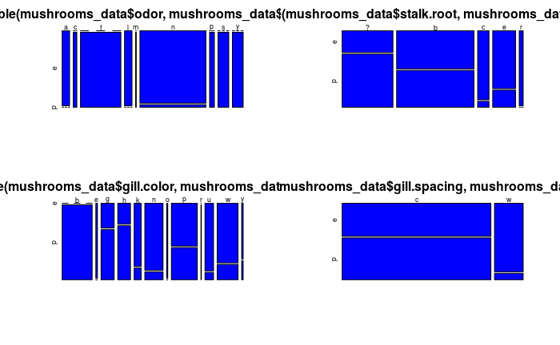

```r
plot(table(mushrooms_data$gill.color, mushrooms_data$class), col = 'blue')
plot(table(mushrooms_data$gill.spacing, mushrooms_data$class), col = 'blue')
```

```r
table(mushrooms_data$odor, mushrooms_data$class)
```

```
       e    p
  a  400    0
  c    0  192
  f    0 2160
  l  400    0
  m    0   36
  n 3408  120
  p    0  256
  s    0  576
  y    0  576
```

```r
table(mushrooms_data$stalk.root, mushrooms_data$class)
```

```
       e    p
  ?  720 1760
  b 1920 1856
  c  512   44
  e  864  256
  r  192    0
```

```r
table(mushrooms_data$gill.color, mushrooms_data$class)
```

```
       e    p
  b    0 1728
  e   96    0
  g  248  504
  h  204  528
  k  344   64
  n  936  112
  o   64    0
  p  852  640
  r    0   24
  u  444   48
  w  956  246
  y   64   22
```

```r
table(mushrooms_data$gill.spacing, mushrooms_data$class)
```

```
       e    p
  c 3008 3804
  w 1200  112
```

Split data into training and test sets

```r
#Split Dataset into training and test sets
# install.packages('caTools')
installAndLoad('caTools')
set.seed(1)
split = sample.split(mushrooms_data$class, SplitRatio = 0.8)
training_set = subset(mushrooms_data, split == TRUE)
test_set = subset(mushrooms_data, split == FALSE)
```

Install H2O if it is not installed already

```r
# Install h2o package if not installed already
if (!("h2o" %in% rownames(installed.packages()))) {
  # Next, we download packages that H2O depends on.
  installAndLoad(c("statmod","RCurl","jsonlite"))
  # Now we download, install and initialize the H2O package for R.
  install.packages("h2o", type="source", repos="http://h2o-release.s3.amazonaws.com/h2o/rel-vajda/4/R")
}
```

Finally, let’s load H2O and start up an H2O cluster

```r
h2o.init(nthreads = -1)
```

```
 Connection successful!

R is connected to the H2O cluster:
    H2O cluster uptime:         1 hours 24 minutes
    H2O cluster version:        3.10.5.4
    H2O cluster version age:    5 days
    H2O cluster name:           H2O_started_from_R_rstudio_gpg616
    H2O cluster total nodes:    1
    H2O cluster total memory:   0.22 GB
    H2O cluster total cores:    1
    H2O cluster allowed cores:  1
    H2O cluster healthy:        TRUE
    H2O Connection ip:          localhost
    H2O Connection port:        54321
    H2O Connection proxy:       NA
    H2O Internal Security:      FALSE
    R Version:                  R version 3.4.0 (2017-04-21)
```

Fitting ANN to training set

```r
classifier = h2o.deeplearning(y = 'class',
                              training_frame = as.h2o(training_set),
                              activation = 'Rectifier',
                              hidden = c(6,6),
                              epochs = 100,
                              train_samples_per_iteration = -2)
```

```
Dropping bad and constant columns: [veil.type].
```

Look at summry of the model

```r
summary(classifier)
```

```
Model Details:
==============

H2OBinomialModel: deeplearning
Model Key:  DeepLearning_model_R_1500757596542_1
Status of Neuron Layers: predicting class, 2-class classification, bernoulli distribution, CrossEntropy loss, 884 weights/biases, 17.9 KB, 659,032 training samples, mini-batch size 1
  layer units      type dropout       l1       l2 mean_rate rate_rms momentum mean_weight
1     1   137     Input  0.00 %
2     2     6 Rectifier  0.00 % 0.000000 0.000000  0.932453 0.240632 0.000000    0.011344
3     3     6 Rectifier  0.00 % 0.000000 0.000000  0.839549 0.378196 0.000000   -0.165359
4     4     2   Softmax         0.000000 0.000000  0.851284 0.351633 0.000000    1.037973
  weight_rms mean_bias bias_rms
1
2   0.191099  0.649018 0.199172
3   0.676195  1.110387 0.129645
4   1.839275 -0.019985 0.076801

H2OBinomialMetrics: deeplearning
** Reported on training data. **
** Metrics reported on full training frame **

MSE:  9.599284e-11
RMSE:  9.797594e-06
LogLoss:  3.286325e-07
Mean Per-Class Error:  0
AUC:  1
Gini:  1

Confusion Matrix (vertical: actual; across: predicted) for F1-optimal threshold:
          e    p    Error     Rate
e      3366    0 0.000000  =0/3366
p         0 3133 0.000000  =0/3133
Totals 3366 3133 0.000000  =0/6499

Maximum Metrics: Maximum metrics at their respective thresholds
                        metric threshold    value idx
1                       max f1  0.999906 1.000000  54
2                       max f2  0.999906 1.000000  54
3                 max f0point5  0.999906 1.000000  54
4                 max accuracy  0.999906 1.000000  54
```

[output cut: 25 more lines]

```
        variable relative_importance scaled_importance percentage
1   stalk.root.b            1.000000          1.000000   0.031653
2         odor.n            0.860708          0.860708   0.027244
3         odor.f            0.824453          0.824453   0.026097
4   gill.color.b            0.795853          0.795853   0.025191
5 gill.spacing.c            0.684036          0.684036   0.021652

---
                       variable relative_importance scaled_importance percentage
132     ring.number.missing(NA)            0.000000          0.000000   0.000000
133    gill.spacing.missing(NA)            0.000000          0.000000   0.000000
134       gill.size.missing(NA)            0.000000          0.000000   0.000000
135         bruises.missing(NA)            0.000000          0.000000   0.000000
136     stalk.shape.missing(NA)            0.000000          0.000000   0.000000
137 gill.attachment.missing(NA)            0.000000          0.000000   0.000000
```

Predicting test set results

```r
prob_pred = h2o.predict(classifier, newdata = as.h2o(test_set[-1]))
y_pred = prob_pred$predict
y_pred = as.vector(y_pred)
```

Model accuracy

```r
# validation accuracy
plot(classifier)
```

[output not shown]

```r
par(mfrow=c(2,2))
plot(classifier, timestep = "epochs", metric = "classification_error")
plot(classifier, timestep = "epochs", metric = "rmse")
```

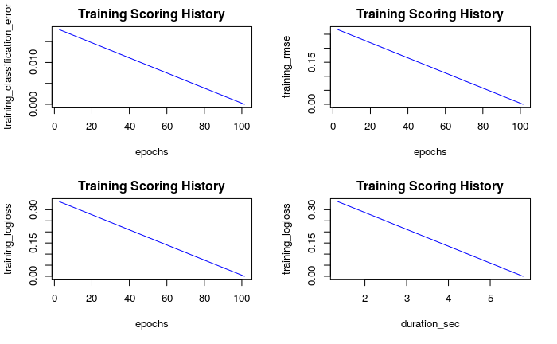

```r
plot(classifier, timestep = "epochs", metric = "logloss")
plot(classifier, timestep = "duration", metric = "logloss")
```

Scoring history

```r
h2o.scoreHistory(classifier)
```

```
Scoring History:
            timestamp   duration training_speed    epochs iterations       samples
1 2017-07-22 21:14:19  0.000 sec                  0.00000          0      0.000000
2 2017-07-22 21:14:19  1.353 sec  43472 obs/sec   2.66226          1  17302.000000
3 2017-07-22 21:14:24  5.785 sec 144810 obs/sec 101.40514         38 659032.000000
  training_rmse training_logloss training_auc training_lift training_classification_error
1
2       0.26628          0.33646      0.98934       2.07437                       0.01785
3       0.00001          0.00000      1.00000       2.07437                       0.00000
```

Apply grid search to find optimal hyperparameters. We will test with activation, L1, and L2

```r
activation_opt <- c("Rectifier", "Maxout", "Tanh")
l1_opt <- c(0, 0.00001, 0.0001, 0.001, 0.01)
l2_opt <- c(0, 0.00001, 0.0001, 0.001, 0.01)

hyper_params <- list(activation = activation_opt, l1 = l1_opt, l2 = l2_opt)
search_criteria <- list(strategy = "RandomDiscrete", max_runtime_secs = 600)

splits <- h2o.splitFrame(as.h2o(training_set), ratios = 0.8, seed = 1)

dl_grid <- h2o.grid("deeplearning", x = colnames(training_set[,-1]), y = 'class',
                    grid_id = "dl_grid",
                    training_frame = splits[[1]],
                    validation_frame = splits[[2]],
                    seed = 1,
                    hidden = c(20,20),
                    hyper_params = hyper_params,
                    search_criteria = search_criteria)

dl_gridperf <- h2o.getGrid(grid_id = "dl_grid",
                           sort_by = "accuracy",
                           decreasing = TRUE)
```

```r
print(dl_gridperf)
```

```
H2O Grid Details
================

Grid ID: dl_grid
Used hyper parameters:
  -  activation
  -  l1
  -  l2
Number of models: 75
Number of failed models: 0

Hyper-Parameter Search Summary: ordered by decreasing accuracy
  activation     l1     l2        model_ids accuracy
1  Rectifier 1.0E-5  0.001 dl_grid_model_56      1.0
2  Rectifier 1.0E-4   0.01 dl_grid_model_62      1.0
3     Maxout    0.0 1.0E-4 dl_grid_model_53      1.0
4  Rectifier    0.0 1.0E-5  dl_grid_model_3      1.0
5       Tanh    0.0    0.0 dl_grid_model_18      1.0

---
   activation    l1     l2        model_ids           accuracy
70       Tanh 0.001    0.0 dl_grid_model_11 0.9953560371517027
71       Tanh 0.001 1.0E-5  dl_grid_model_5 0.9953560371517027
72       Tanh 0.001 1.0E-4 dl_grid_model_46 0.9953560371517027
73     Maxout 0.001 1.0E-4 dl_grid_model_27 0.9821981424148607
74     Maxout 0.001 1.0E-5 dl_grid_model_35 0.9821981424148607
75     Maxout 0.001    0.0 dl_grid_model_23 0.9821981424148607
```

Get best model out

```r
best_dl_model_id <- dl_gridperf@model_ids[[1]]
best_dl <- h2o.getModel(best_dl_model_id)

best_dl_perf <- h2o.performance(model = best_dl, newdata = as.h2o(test_set))
h2o.mse(best_dl_perf)
```

[output not shown]

Compare best model with our original model

```r
print('Best Model performance:')
```

```
[1] "Best Model performance:"
```

```r
h2o.confusionMatrix(best_dl_perf)
```

```
Confusion Matrix (vertical: actual; across: predicted)  for max f1 @ threshold = 0.0767206094637224:
         e   p    Error     Rate
e      842   0 0.000000   =0/842
p        0 783 0.000000   =0/783
Totals 842 783 0.000000  =0/1625
```

```r
h2o.mse(best_dl_perf)
```

```
[1] 0.01501816
```

Original classifier

```r
print('Original Model performance:')
```

```
[1] "Original Model performance:"
```

```r
h2o.confusionMatrix(classifier)
```

```
Confusion Matrix (vertical: actual; across: predicted)  for max f1 @ threshold = 0.999905763754095:
          e    p    Error     Rate
e      3366    0 0.000000  =0/3366
p         0 3133 0.000000  =0/3133
Totals 3366 3133 0.000000  =0/6499
```

```r
h2o.mse(classifier)
```

```
[1] 9.599284e-11
```

Summary of best model:

```r
summary(best_dl_perf)
```

```
            Length              Class               Mode
                 1 H2OBinomialMetrics                 S4
```

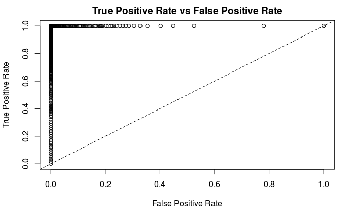

```r
plot(best_dl_perf)
```

```r
h2o.shutdown()
```